# Kamron Brooks

###### [ [👨‍💻 Github](https://www.github.com/healyhatman) ] - [ [🌐 Web](https://skyspider.com.au) ] - [ 📧 kamron@skyspider.com.au ] - [📞 0438 KAMRON (526 766) ]

#### Full Stack Developer | Expert in Laravel/PHP, SQL Server | Xero & KeyPay Integration Specialist | Vue.js & TypeScript Enthusiast

## Skills

`Laravel` `PHP` `Testing Frameworks [ PHPUnit | Cypress ]` `SQL Server` `Typescript` `Vue` `API Integration [ Xero | KeyPay | Dex ]` `Git` `SCHADS Award` `Jira | Bitbucket | Confluence`

**Languages**: PHP, Javascript / TypeScript **Databases**: SQL Server, MySQL **Tools**: Git

## Experience

### CareMaster Global Pty Ltd

#### Full stack developer, Jun 2019 - Apr 2024

##### Key responsibilities

- Developed and maintained robust backend systems using Laravel/PHP and SQL Server, prioritizing performance, scalability, and reliability.
- Developed a Xero-connected payroll system with award interpretation in consultation with Fair Work Australia
- Implemented comprehensive PHPUnit tests to validate backend functionality and uphold code quality standards.
- Designed and developed interactive frontend interfaces using Vue.js and TypeScript, enhancing user experience and usability.
- Conducted query optimization to enhance database performance, particularly with complex queries, improving efficiency and responsiveness.
- Created custom reports to export data in PDF and .xlsx formats, ensuring accessibility and usability of critical information.

##### Notable technical achievements

###### Xero Integration

- Led the successful development and certification of a comprehensive Xero integration, enabling seamless data synchronization and financial management.
- Achieved certification as an official Xero App Partner, demonstrating expertise in integration design and compliance with Xero’s standards.
- Collaborated closely with stakeholders to understand business requirements and deliver a tailored integration solution that met client needs.
- Implemented robust security measures and data handling practices to ensure the integrity and privacy of financial information exchanged with Xero.
- Provided ongoing support and maintenance for the Xero integration, including updates to accommodate platform changes and feature enhancements.

###### Keypay Integration

- Successfully applied as a KeyPay developer partner
- Developed an OAuth 2.0 client to allow secure tokenised communication with the KeyPay API
- Generated a comprehensive integration using the OpenAPI v2 specification provided, with modifications to allow for ODAta queries, using OpenAPI generator

###### DEX Integration

- Developed solution to sync client and session data to and from the Data Exchange system via the DEX API.
  - Sync and search clients
  - Create and update cases and attached sessions
  - Sync and enforce activity requirements

###### Payroll

- Engineered a comprehensive payroll system from inception, ensuring compliance with the Social, Community, Home Care and Disability Services, and Children’s Services awards.
- Collaborate effectively with Fair Work Australia to ensure edge cases generate accurate recommendations
- Expertly manages complex payroll calculations ensuring precision and accuracy.
  - Hours worked
  - Overtime
  - Penalty and public holiday rates
  - Allowances
- Collaborated effectively with diverse systems to offer seamless payroll integrations:
  - Xero (via API)
  - KeyPay (via API; repository at github.com/Healyhatman/keypay-php)
  - Elmo (via .csv)
  - MYOB (via .csv)
  - Reckon (via .iif and .csv)

###### Invoicing

- Generated precise invoices based on verified participant supports for Plan Managed and other services, ensuring accuracy and compliance.
- Implemented seamless integration with financial systems:
  - Synchronized invoices with Xero for streamlined financial management.
  - Exported invoices to .iif/.csv formats compatible with MYOB and Reckon.

###### Home Care Packages

- Engineered a robust solution to meticulously track income and expenditures for participants with Home Care Packages, ensuring accuracy and transparency.
- Implemented a system that generates polished PDF statements, delivering clear and comprehensible financial reports to clients.

###### Screenshots

[figure not shown]

Home care package statement

*A generated home care package statement PDF cover page. Please note that this is using a fake client with seeded data, so there are no privacy implications.*

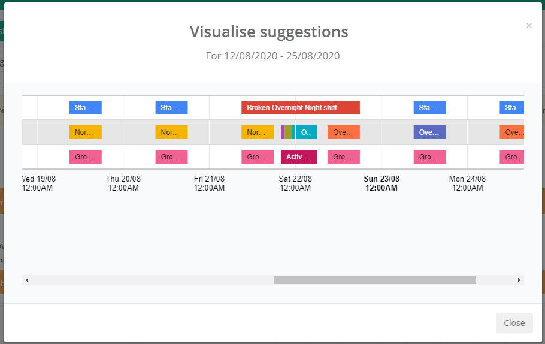

Visualised payroll suggestions

*A Google Charts driven visualisation of the payroll shift, individual payment periods with types, and parent support times from which they were made.*

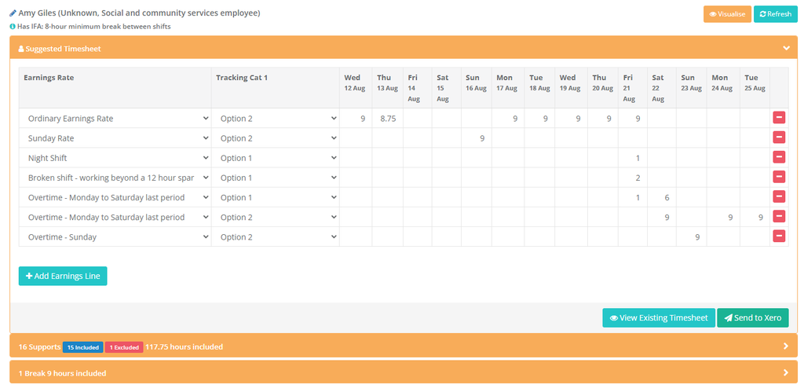

Payroll suggestions for Xero

*Suggestions generated for a Xero Timesheet entry for a given (fake) worker, including Shift rates and overtime. Allowances in Xero are applied to the payslip itself at a later stage.*

## Projects

**[*oauth2-keypay*](https://github.com/Healyhatman/oauth2-keypay)**

Provides KeyPay OAuth 2.0 supoport for the PHP League’s OAuth 2.0 Client

**[*keypay-php*](https://github.com/Healyhatman/keypay-php)**

A client library for the KeyPay API, built from the provided OpenAPI v2 specification using the OpenAPI Generator

## Education

### Swinburne University

**Degree:** Bachelor of Technology (Information Systems) with minors in Business and Economics | **Years Attended:** 2013-2016 | **Attended via:** Open Universities